# Home Work-3

### Submitted by:- Rupakula Sai Abhishek

# Problem 1: Neural Network for Source Separation

Loading Both trs.wav and trn.wav using librosa library

```python
import numpy as np
import matplotlib.pyplot as plt
from scipy.io import wavfile
from sklearn.decomposition import PCA
import seaborn as sns
import IPython.display as ipd
from scipy.signal import stft, istft
import librosa


s,rate1=librosa.load('trs.wav',sr=16000)
n,rate2=librosa.load('trn.wav',sr=16000)

s.shape,n.shape
```

```
((403255,), (403255,))
```

Creating a noisy signal x by adding up both s and n

```python
x=s+n
x.shape
```

```
(403255,)
```

Tranforming all the 3 vectors using STFT

```python
S=librosa.stft(s, n_fft=1024, hop_length=512,window='hann')
N=librosa.stft(n, n_fft=1024, hop_length=512,window='hann')
X=librosa.stft(x, n_fft=1024, hop_length=512,window='hann')

X=np.abs(X)
X.shape
```

```
(513, 788)
```

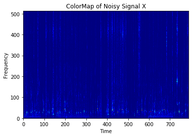

```python
plt.pcolormesh(X,cmap='jet')
plt.title("ColorMap of Noisy Signal X")
plt.xlabel("Time")
plt.ylabel("Frequency")
```

Let us create an IBM Mask M by comparing Signal S and N

```python
N=np.abs(N)
S=np.abs(S)
M = (S > N).astype(int)
M.shape
```

```
(513, 788)
```

Let us Train A shallow Neural Network for this probelem

```python
class NN:
    #  Defining the Activation function and its derivative
    def __init__(self,learning_rate,epochs):
        self.learning_rate = learning_rate
        self.epochs=epochs

    def reLU(self,x):
        return np.maximum(0.0,x)

    def relu_derivative(self,x):
        x[x<=0] = 0
        x[x>0] = 1
        return x


    def Logistic(self,x):
        k=1/(1+np.exp(-x))
        return k

    def Logistic_derivative(self,x):
        k = 1/(1+np.exp(-x))
        return k * (1 - k)

    #forward propagation of the network
    def forward_propagation(self,Input):
        self.L_1 = np.dot(self.w1.T,Input)+self.b1
        self.A_1 = self.reLU(self.L_1)
        self.L_2 = np.dot(self.w2.T,self.A_1)+self.b2
        self.A_2 = self.Logistic(self.L_2)


    #Weights and biases are updated
    def backward_propagation(self,Input,Target):
        self.e=np.subtract(self.A_2 ,Target)
        self.k=(self.e) * self.Logistic_derivative(self.L_2)
        self.dw2= np.dot(self.A_1,self.k.T)
        self.db2=np.sum(self.k)



        self.e2= np.dot(self.w2,self.k)
        self.k2= (self.e2) * self.relu_derivative(self.L_1)
        self.dw1= np.dot(Input,self.k2.T)
        self.db1=np.sum(self.k2)



        self.w2 = self.w2 - self.learning_rate*self.dw2
        self.w1 = self.w1 - self.learning_rate*self.dw1
        self.b1= self.b1- self.learning_rate*self.db1
        self.b2= self.b2- self.learning_rate*self.db2


    def Network(self,Input,Target):
        np.random.seed(9)
        #self.loss={}
        self.error = []
        self.w1 = np.random.randn(513,50)*0.00001
        self.w2 = np.random.randn(50,513)*0.00001
        self.b1 = np.random.randn(50,1)*0.00001
        self.b2 = np.random.randn(513,1)*0.00001



        for i in range(self.epochs):

            self.forward_propagation(Input)
            squared_error=np.sum(0.5*np.square(self.A_2-Target))/((Target.shape[0])*(Target.shape[1]))
            self.error.append(squared_error)
            #print(self.error)
            self.backward_propagation(Input,Target)



        lm=np.array(self.error)
        plt.plot(self.error)
        plt.title("Convergence Graph")
        plt.xlabel("Iterations")
        plt.ylabel("Error")



    def Predict(self,Input):
        self.forward_propagation(Input)
        return self.A_2
```

[figure not shown]

```python
Classifier= NN(0.00005,40000)
Classifier.Network(X,M)
```

Loading the test and corresponding ground truth signal tex.wav and tes.wav

```python
test,rate3=librosa.load('tex.wav',sr=16000)
clean,rate4=librosa.load('tes.wav',sr=16000)
```

STFT on test

```python
Test=librosa.stft(test, n_fft=1024, hop_length=512,window='hann')
```

Let us predict the masks for our noisy test signal using the trained Network

```python
Test_masks=Classifier.Predict(np.abs(Test))
```

Lets recover the speech spectogram of test signal by muliplying Test with predicted masks

```python
recover=np.multiply(Test,Test_masks)
```

Perform istft on recover to get the time domian signal

```python
out=librosa.istft(recover,hop_length=512,length=len(clean))
ipd.display(ipd.Audio(out,rate=16000))
```

[interactive chart not shown]

Now let us calculate the SNR value based on our recovered signal(s_hat) and our actual clean signal(s)

```python
s= clean.reshape(-1,1)
s_hat = out.reshape(-1,1)
s.shape,s_hat.shape
```

```
((50791, 1), (50791, 1))
```

```python
a=np.dot(s.T,s_hat)
b=np.dot((s-s_hat).T,(s-s_hat))
SNR=10*np.log10(a/b)

print("The SNR Value is ",float(SNR))
```

```
The SNR Value is  6.785102367401123
```

The SNR value is greater than 6 (SNR>6) which was expected form this question.

From My observation the SNR Value can be increased further if we increase the number of epohs.With my learning rate and epohs SNR value close to 7 is achieved.

# Problem 2: Stereo Matching (revisited)

Loading both the images from 2 positions

```python
import numpy as np
import matplotlib.pyplot as plt
import seaborn as sns
import IPython.display as ipd
import scipy.io
import matplotlib.image as mpimg
from scipy.stats import norm
from scipy.spatial import distance

Left=mpimg.imread('im0.ppm')
Right=mpimg.imread('im8.ppm')
Left.shape,Right.shape
```

```
((381, 430, 3), (381, 430, 3))
```

[figure not shown]

```python
plt.imshow(Left)
plt.title("Left Image")
```

[figure not shown]

```python
plt.imshow(Right)
plt.title("Right Image")
```

Calculating the Disparity Map based on left and right images

```python
Disparity_map=np.zeros((381,390))

for i in range(Left.shape[0]):
    for j in range(Left.shape[1]-40):
        indexes=[]
        for k in range(0,40):
            l=np.linalg.norm(Left[i,j+k,:]- Right[i,j,:])
            indexes.append(l)
        minimum_matrix=np.argmin(indexes)
        Disparity_map[i][j]=minimum_matrix
```

Let's Vectorize the image and draw a histogram

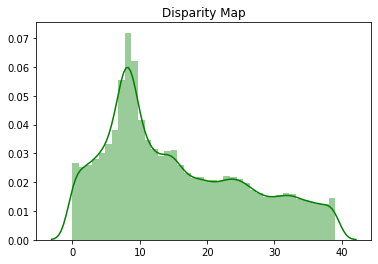

```python
Disparity_map_flatten=Disparity_map.flatten()
sns.distplot(Disparity_map_flatten,bins=40,color="green")
plt.title("Disparity Map")
```

For The Above graph I can see 4 clusters formed.

Let us cluster the disparity values by using GMM clustering (Reused my GMM code from HomeWork-2)

```python
# We can see 4 clusters
def E_step(probabilities,Variances,disparity_values,Means):
    values={}
    u1=(1/np.sqrt(2*np.pi* Variances[0]))* np.exp((-1/2)*np.square((disparity_values-Means[0]))*(1/Variances[0]))
    u2=(1/np.sqrt(2*np.pi* Variances[1]))* np.exp((-1/2)*np.square((disparity_values-Means[1]))*(1/Variances[1]))
    u3=(1/np.sqrt(2*np.pi* Variances[2]))* np.exp((-1/2)*np.square((disparity_values-Means[2]))*(1/Variances[2]))
    u4=(1/np.sqrt(2*np.pi* Variances[3]))* np.exp((-1/2)*np.square((disparity_values-Means[3]))*(1/Variances[3]))
    #U=np.column_stack((values[0],values[1]))
    U=np.column_stack((u1,u2,u3,u4))

    for j in range(0,len(U)):
        p1=probabilities[0]*U[j,0]
        p2=probabilities[1]*U[j,1]
        p3=probabilities[2]*U[j,2]
        p4=probabilities[3]*U[j,3]

        U[j,0]= np.divide(p1,p1+p2+p3+p4)
        U[j,1]= np.divide(p2,p1+p2+p3+p4)
        U[j,2]= np.divide(p3,p1+p2+p3+p4)
        U[j,3]= np.divide(p4,p1+p2+p3+p4)

    return U


def M_step(U,probabilities,Variances,disparity_values,Means):

        m1=(U[:,0].dot(disparity_values))/sum(U[:,0])
        m2=(U[:,1].dot(disparity_values))/sum(U[:,1])
        m3=(U[:,2].dot(disparity_values))/sum(U[:,2])
        m4=(U[:,3].dot(disparity_values))/sum(U[:,3])
        Means=np.array([m1,m2,m3,m4])

        var1=(U[:,0].dot(np.square(disparity_values-m1)))/sum(U[:,0])
        var2=(U[:,1].dot(np.square(disparity_values-m2)))/sum(U[:,1])
        var3=(U[:,2].dot(np.square(disparity_values-m3)))/sum(U[:,2])
        var4=(U[:,3].dot(np.square(disparity_values-m4)))/sum(U[:,3])
        Variances=np.array([var1,var2,var3,var4])

        prob1=np.divide(sum(U[:,0]),len(U[:,0]))
        prob2=np.divide(sum(U[:,1]),len(U[:,1]))
        prob3=np.divide(sum(U[:,2]),len(U[:,2]))
        prob4=np.divide(sum(U[:,3]),len(U[:,3]))
        probabilities=np.array([prob1,prob2,prob3,prob4])






        return Means,Variances,probabilities
```

Let us initialize the means,probabilites,Variances and then use our GMM steps to update them

```python
#Initialization of mean,prob and variance
clusters=4
p= np.random.random(clusters)
probabilities=p/p.sum()
Variances=np.random.randint(0,40,clusters)
Means=np.random.randint(0,40,clusters)
```

```python
for i in range (clusters):
    U=E_step(probabilities,Variances,Disparity_map_flatten,Means)
    Means,Variances,probabilities= M_step(U,probabilities,Variances,Disparity_map_flatten,Means)
```

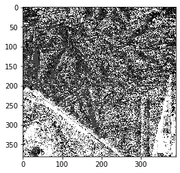

```python
levels=np.argmax(U,axis=1)
depth_map=np.choose(levels,Means).reshape((381,390))
plt.imshow(depth_map,cmap="gray")
```

As we see from the gray scale image that frontline objects are brighter and back images are darker.

Lets Implement MRF smoothing using ICM sampling

```python
smoothen=U.reshape((381,390,4))

def kernel(first,second):
    if first==second:
        pos = 0
    else:
        pos=3
    prob=np.square(pos)
    p = np.exp(-(prob)/(3))
    return p
```

```python
for iterations in range(5):
    for i in range(0,380):
        for j in range(0,389):


            Neighbours =[[i-1,j-1],[i-1,j],[i-1,j+1],[i,j-1],[i,j+1],[i+1,j-1],[i+1,j],[i+1,j+1]]
            smooth_points=[]


            for clusters in range(4):

                    for k,l in Neighbours:


                        MRF=kernel(clusters,np.argmax(smoothen[k,l]))
                        smooth_points.append(MRF)

                    product=np.prod(smooth_points)
                    smooth_points=[]
                    smoothen[i][j][clusters]=(smoothen[i][j][clusters]*product)
```

```python
smoothen=smoothen.reshape((148590, 4))
number=np.argmax(smoothen,axis=1)
depth_map=np.choose(number,Means).reshape((381,390))
```

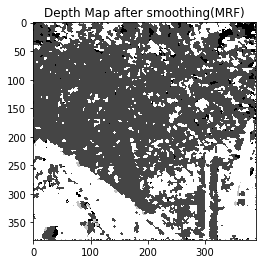

```python
plt.imshow(depth_map,cmap="gray")
plt.title("Depth Map after smoothing(MRF)")
```

As we see our depth map has smoothened in this case

# Problem 3: Rock or Metal

Loading both the trX.mat and trY.mat matrices

```python
import numpy as np
import matplotlib.pyplot as plt
from scipy.io import loadmat
import math
from scipy.spatial.distance import pdist, squareform
import matplotlib.pyplot as plt

data=loadmat('trX.mat')
trX=data['trX']
trX.shape
```

```
(2, 160)
```

```python
data=loadmat('trY.mat')
trY=data['trY']
trY.shape
```

```
(1, 160)
```

Before we start implementing our ADAboost training algorithm we first need to implement a weak classifier. In our case let us conisder a perceptron as weak classifier

Perceptron with no hidden layers

```python
def Perceptron(X,Y,W_M,learning_rate,epohs):

    #Initializing Learning Rate and Epohs
    learning_rate=learning_rate
    epohs=epohs
    error = []

    #Initialize Weights
    weights = np.random.randn(1,2)*0.00001
    bias = np.random.randn(1,1)*0.000001


    for i in range(epohs):



            #Forward
        L_1 = np.dot(weights,X)+bias
        A_1 = np.tanh(L_1)


        e1=np.sum(0.5*W_M*(np.square(Y-A_1)))
        error.append(e1)



        e=(Y-A_1)*W_M*(1-np.tanh(L_1)**2)
        dw = np.dot(e,X.T)
        weights = weights +learning_rate*dw
        bias=bias+learning_rate*np.sum(e)



    return A_1,weights,bias
```

Implementation of AdaBoost Training algorithm.

The major step in ada boosting is $fm (x) = f(m-1) (x) + \beta_m* \phi_m$

here $\phi_m$ is our weak classifier. perceptron in this case.

and $\beta_m=\frac{1}{2}ln\frac{\sum_{t=1}^T w_t*I(y_t = \phi_m(x_t)) }{\sum_{t=1}^T w_t*I(y_t \neq \phi_m(x_t))}$

```python
def ada_boost(Weak_learner,X,Y,learning_rate,epochs):
    W_M = []
    beta =[]
    phi =[]
    perceptron_w=[]
    bias=[]
    weight_m = np.ones((1,X.shape[1])) * (1/X.shape[1])
    Err=[]

    for m in range(Weak_learner-1):

        Y_pred,perceptron_weights,bias= Perceptron(X,Y,weight_m,learning_rate,epochs)

        p=np.sign(Y_pred)
        phi.append(p)


        #b= (1/2)*np.log(weight_m*(np.sum(np.where(Y==p,1,0)))/weight_m*(np.sum(np.where(Y!=p,1,0))))
        num=weight_m*(np.sum(np.where(Y==p,1,0)))
        denom=weight_m*(np.sum(np.where(Y!=p,1,0)))
        b= (1/2)*np.log(num/denom)
        beta.append(b)

        weight_m=weight_m*np.exp(-b*Y*p)
        weight_m=weight_m/np.sum(weight_m)
        W_M.append(weight_m)

    W_M=np.array(W_M)
    beta=np.array(beta)
    phi=np.array(phi)

    return beta,phi,W_M
```

```python
beta,phi,W_M=ada_boost(200,trX,trY,0.005,10000)
fx=beta*phi
Y_pred=np.sum(fx,axis=0)
beta.shape,phi.shape,W_M.shape,Y_pred.shape
```

```
((199, 1, 160), (199, 1, 160), (199, 1, 160), (1, 160))
```

```python
count=0
for i in range(Y_pred.shape[1]):
    pred=np.sign(Y_pred[0,i])
    if (pred==trY[0,i]):
        count=count+1
    acc=(count/trY.shape[1])
    acc=acc*100

print("The Classification Accuracy is",acc)
```

```
The Classification Accuracy is 78.125
```

# Problem 4: PLSI for Analyzing Twitter Stream

Loading twitter.mat which contain train and test data of term frequencies and Targets

```python
import numpy as np
import matplotlib.pyplot as plt
import seaborn as sns
import scipy.io

data = scipy.io.loadmat('twitter.mat')
```

```python
Xte=data['Xte']
Xtr=data['Xtr']
Yte=data['YteMat']
Ytr=data['YtrMat']
Xtr.shape,Xte.shape,Ytr.shape,Yte.shape
```

```
((891, 773), (891, 193), (3, 773), (3, 193))
```

I have Used the Matrix Approach to Implement Probabilistic Latent Semantic Indexing(PLSI)

There are 2 key terms in while Implementing PLSI B and $\Theta$

In the Matrix Approach we merege both the E-step and the Mstep

The way we calculate it is

$B= B*(\frac{X}{B\Theta}*\Theta^T)$ $B=\frac{B}{1^v * B}$

$\Theta= \Theta*(B^T*\frac{X}{B\Theta})$ $\Theta=\frac{\Theta}{1^k * \Theta}$

Let us first use the train data and get the B and $\Theta$ Values

```python
np.random.seed(9)
B=np.random.rand(891,50)
Theta=np.random.rand(50,773)
ones_B=np.ones((891,891))
ones_theta=np.ones((50,50))


def PLSI(data,B,Theta,ones_B,ones_theta):
    error=[]

    for i in range (0,1000):
        B_mul=np.matmul(np.divide(data,np.matmul(B,Theta)+1e-10),Theta.T)
        B=np.multiply(B,B_mul)
        B= np.divide(B,np.matmul(ones_B,B)+1e-10)

        Theta_mul=np.matmul(B.T,np.divide(data,np.matmul(B,Theta)+1e-10))
        Theta=np.multiply(Theta,Theta_mul)
        Theta=Theta+1e-10
        Theta=np.divide(Theta,np.matmul(ones_theta,Theta)+1e-10)


    return B,Theta
```

```python
B_updates,Theta_updated=PLSI(Xtr,B,Theta,ones_B,ones_theta)
```

Now We have our B and $\Theta$ values for the train

Let us now get the $\Theta$ values for test. As directed in Point 4 of question I am Using the same B values that we obtained above

```python
np.random.seed(9)
Theta_test=np.random.rand(50,193)
ones_theta=np.ones((50,50))

def PLSI_theta(data,B,Theta,ones_theta):


    for i in range (0,1000):

        Theta_mul=np.matmul(B.T,np.divide(data,np.matmul(B,Theta)+1e-10))
        Theta=np.multiply(Theta,Theta_mul)
        Theta=Theta+1e-10
        Theta=np.divide(Theta,np.matmul(ones_theta,Theta)+1e-10)

        return Theta
```

```python
Theta_test_updated=PLSI_theta(Xte,B_updates,Theta_test,ones_theta)
```

Let us train our Perceptron Model using softmax classification

```python
Theta_updated=Theta_updated.T
Ytr=Ytr.T
```

```python
def softmax(x):
    e_x=np.exp(x)
    return e_x / e_x.sum(axis=1,keepdims=True)


#Initializing Learning Rate and Epohs
learning_rate=0.03
epohs=50000
error = []
error1=[]


#Initialize Weights
np.random.seed(9)
weights = np.random.randn(50,3)
bias = np.random.randn(3)



#Backpropagation To train our network
for i in range(epohs):
    L_1 = np.dot(Theta_updated,weights)+bias
    A_1 = softmax(L_1)


    err=-np.sum(Ytr * np.log(A_1))
    error.append(err)

    e=A_1-Ytr
    dw=np.dot(Theta_updated.T,e)
    db=np.sum(e,axis=0,keepdims=True)
    weights = weights -learning_rate*dw
    bias=bias-learning_rate*db



#plt.plot(np.arange(0, len(error)),error)
#plt.title("Convergence Graph")
#plt.xlabel("Iterations")
#plt.ylabel("Error")
```

Now Let us calculate the Training and testing accuracy

Trainning Accuracy

```python
#Calling Our perceptron
input_layer= np.dot(Theta_updated,weights)+bias
activated=softmax(input_layer)


#Calculating the Accuracy of the Model
Y_predicted=np.where(activated>=0.5,1,0)
acc=[]
for i in range (0,len(Ytr)):
    l=np.sum(np.allclose(Ytr[i],Y_predicted[i]))
    acc.append(l)

accuracy=np.mean(acc)

print("Train Accuracy is ",accuracy*100)
```

```
Train Accuracy is  59.76714100905562
```

Testing Accuracy:

```python
Theta_test_updated=Theta_test_updated.T
Yte=Yte.T
#Calling Our perceptron
input_layer= np.dot(Theta_test_updated,weights)+bias
activated=softmax(input_layer)


#Calculating the Accuracy of the Model
Y_predicted=np.where(activated>=0.5,1,0)
acc=[]
for i in range (0,len(Yte)):
    l=np.sum(np.allclose(Yte[i],Y_predicted[i]))
    acc.append(l)

accuracy=np.mean(acc)

print("Test Accuracy is ",accuracy*100)
```

```
Test Accuracy is  53.8860103626943
```

Our Training and Testing accuracies are 59.7% and 53.8% respectively